# Intro to EDW

## Quality Improvement data

### Motivation

- We used Excel for nearly everything
- Excessive time spent copying & pasting data, emailing files, cleaning/fixing errors, etc.

### Needed a solution that was:

- Inexpensive and did not require software installation (Cheap)
- Compliant / Data Management Best Practices (Good)
- Easy to develop, deploy & use (Fast)

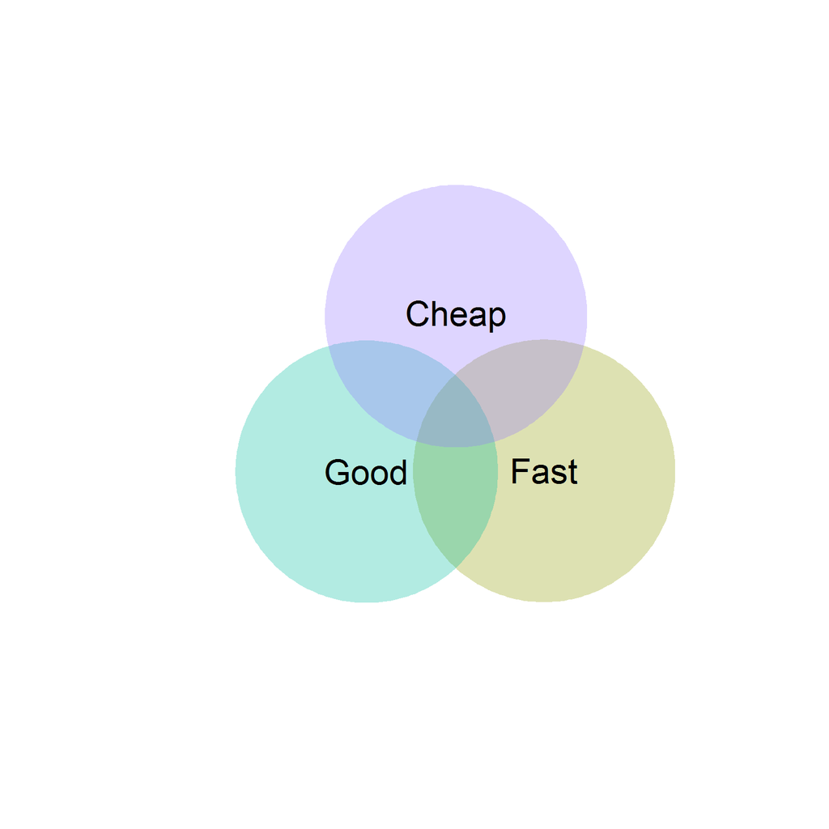

## What is REDCap?

- Secure, web-based application for building and managing online surveys and databases.
- Primary focus is data management for clinical research.
- Free (Funded by NIH grant).

### Key Features

- Intuitive user interface that streamlines the design process.
- No database experience is needed to begin using the software.
- Built-in online support/training videos
- Users can independently make project modifications, even after data collection has begun.
- Project owners have autonomy and control to add new users

## >1700 Institutions Worldwide

[figure not shown]

## How it's used locally

### QI Registries

- Cardiac Level I
- Transcatheter Valve Cases
- Total Joint Replacements

### QI Audits

- Sepsis Bundle compliance
- Delirium (CAM) screening
- Diabetes Management audits

### Operational Projects

- PHC Serious Safety Events
- Workplace Violence Log

### IRB-approved Research

- Prescription Drug Assistance Program
- Spine Surgery Pain Protocol
- Nursing Barriers to Patient Mobility

## Additional Resources

[OCTRI](http://www.ohsu.edu/xd/research/centers-institutes/octri/resources/octri-research-services/project-based-data-collection.cfm) OHSU REDCap site

[ITHS](https://www.iths.org/RCBG) U of W REDCap site